# Data Visualization Final Project: Health Insurance Coverage in the United States

Grace Kong, Iris Chen & Fang Liu (Group P)

# Introduction

## Goals of the project

In this project, we present a *state-level overview* of the expansion of health insurance in the United States and its effects on health outcomes and cost outcomes, from 2008 to 2015 under President Obama’s term. One of the hallmarks of Obama’s presidency was the passage and implementation of the **Affordable Care Act (ACA)** to increase health insurance coverage and regulate healthcare provision to protect consumers’ rights. In addition, we are also interested in how people perceive the (ACA), as seen from articles related to the ACA from the New York Times.

**Research Questions:**

1. *Trends of health insurance expansion in the United States*: How has the percentage of uninsured Americans changed overall, and differentially by states, from 2008 to 2015? How has the composition of healthcare sources changed?
2. *Health outcomes*: How do the states compare in health outcomes, such as mortality rates and access to preventative and remedying treatments?
3. *Financial outcomes*: How do the states compare in financial and cost outcomes, such as the containment of out-of-pocket costs, insurance premium growth and government spending?
4. *Perceptions of the ACA*: We used API to download articles realted to ACA on New York Times from 2011-2017 and transformed them into a corpus to conduct a text analysis. How has the overall trend of public attention changed over the years, as seen by the number of articles relating to the ACA? What topics do people focus on when they discuss the ACA?

## Overview of the Affordable Care Act in the United States

The **Patient Protection and Affordable Care Act (ACA)**, also commonly known as Obamacare, was a major and wide-sweeping healthcare reform initiative enacted by Preseident Obama. The ACA was signed into law by Obama on March 23, 2010, and changes were gradually implemented over the next few years, though the majority of the provisions went into effect only on January 1, 2014.

The major goal of the ACA is to expand health insurance and healthcare access to those who otherwise did not have access, including the 45 million Americans who were uninsured before the ACA took effect. In addition, it also covers wide-ranging regulations for the protection of healthcare consumer rights. Prior to the ACA, many low-income Americans we unable to afford any health insurance, while people with disabilities and pre-existing conditions may have been denied coverage by insurerers.

**The key provisions of the ACA include**

*Employer mandate*: Employers with more than 50 employees are required to provide health insurance to full-time workers, or would otherwise face a fine

*Individual mandate*: Individuals must obtain “minimum essential coverage” for healthcare, and those without health insurance must pay a fine in their annual tax returns to the IRS

*State and federal marketplaces*: These health insurance exchanges were set-up to enable people “shopping” for insurance to make easy comparisons among the insurance plans available, thus inreasing competition in the marketplace as well.

*Federal subsidies* to people earning between 138% and 400% of the FPL to afford monthly health insurance premiums.

*Regulations* preventing insurance companies from discriminating in price and provision based on people’s age, gender, or pre-existing conditions

These provisions of the ACA make health insurance accessible and affordable to people previously without coverage. In addition, people who already have health insurance would also benefit from increased choice, a cap on out-of-pocket expenses, as well as more comprehensive coverage, as insurance is now required to cover more basic treatments than before.

However, this increased coverage comes at a cost of increased premium growths for consumers, and increases in federal spending. The expansion of health insurance and healthcare coverage is projected to cost of the U.S. government up to $1.34 trillion over the next decade. It is thus no surprise that the States fall on various sides of the political spectrum when it comes to support for medicaid.

# (1) Health Insurance Coverage

Access our Shiny App on [Uninsured Rates in the United States from 2008-2015](https://gracekongyx.shinyapps.io/health_insurance_shiny/).

We see a clear downward trend in the uninsured rate once most of the Affordable Care Act (ACA) provisions were implemented in 2014. The overall US uninsured rate decreased from 18.2% in 2010 to 10.5% in 2015.

However, note that the disparities in uninsured rates largely continue to persist among the states, with regional patterns (using Bureau of Economic Analysis (BEA) regions). States of the Southeast and Southwest consistently had the highest uninsured rates, while states of New England consistenely had the lowest insured or highest health insurance coverage rates.

In terms of correlations, it appears that being a Democratic state is a strong predictor of a higher insurance rate. States in New England, the Mideast and the Great Lakes perform well in insurance rates, while states in the Southwest, Rocky Mountains and Southeast perform the poorest. As expected, high-income states have the highest insurance rates as more people would be able to afford insurance. Lower and lower-middle income states have lower coverage rates, but it is infact the lower-middle income states that have the lowest insurance rates.

# (2) Health Outcomes and Access

We note that the Northeast (New England) states perform consistently well across all health outcomes, while the Southeast states, as well as Texes, peform consistently poorly on all except for vaccination rates. The Western and Rocky Mountains states have a low avoidable mortality rate, despite having low rates of access to usual care and of cancer screening and vaccinations. In the measure of adult vaccination rates, the trend of the South faring poorer on health is reversed, as they do comparatively well in vaccinations.

# (3) Affordability and Cost Outcomes

We notice that states that do better in containing OOP costs tend to do worse in containing premium and marketplace plan rates as well as federal spending. These include some states like New York, New Jersey and Ohio in the Northeast and Midwest (Great Lakes). A notable exception is Massachussets, which performs well across the financial measures, possibly because of the headstart it got with “Romney-care”, which actually served as a model for Obamacare.

# Summary of States’ Performance

1. Percentage of population insured
2. Deaths preventable by healthcare intervention (per 100,000 people)
3. Proportion of adults with access to a usual source of care
4. Proportion of people with high out-of-pocket costs (relative to household income)
5. Annual rate of health insurance premium growth from 2010 to 2015

A rank of 1 always indicates the more favorable outcome (i.e. higher insurance and treatment access rate, lower preventable mortality, OOP costs and premium growth)

# (4) Perceptions of ACA (Text Analysis)

**Figure 10**

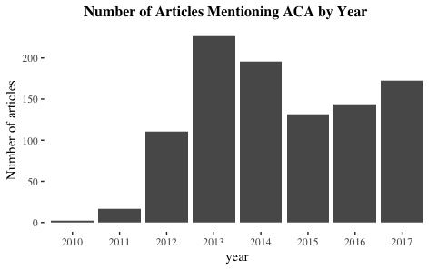

**Figure 11**

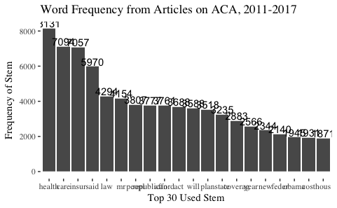